# Aprendizado de Máquina I

### Gabriel Sanfins

#### `gabrielsanfins@id.uff.br`

### 03 - Validação Cruzada

# Relembrando um pouco…

## Formulação matemática

- $Y \in \mathbb{R}$ variável de resposta
- $\mathbf{X} = (X_1, \dots, X_p) \in \mathbb{R}^p$ conjunto de $p$ preditores para $Y$
- Forma geral da relação entre $\mathbf{X}$ e $Y$:
  $$Y = r(\mathbf{X}) + \varepsilon$$
  - $r$ função fixa porém desconhecida
  - Informação sistemática que $\mathbf{X}$ dá sobre $Y$
  - $\varepsilon$ erro de observação (independente de $\mathbf{X}$ e de média zero)

## Formulação matemática

- **Objetivos**: Estimar $r$ a partir de um conjunto de observações $(\mathbf{x}_i, y_i)_{i = 1, \dots, n}$, bem como aferir a *qualidade* de tal estimativa
- **Importante**: Assumiremos observações i.i.d., ou seja, $(\mathbf{X}_1, Y_1), \dots, (\mathbf{X}_n, Y_n) \sim (\mathbf{X}, Y)$
  - O que **não** significa que a distribuição conjunta entre $\mathbf{X}$ e $Y$ será conhecida!
  - Em um mundo ideal, temos $r(\mathbf{x}) = \mathbb{E}[Y | \mathbf{X} = \mathbf{x}]$
- $Y$ quantitativa: problema de *regressão*
- $Y$ qualitativa: problema de *classificação*

## Formulação matemática

- **Objetivo preditivo**: Como podemos criar uma função
  $$g: \mathbb{R}^p \to \mathbb{R}$$
  que tenha *bom poder preditivo*? Isto é, como criar $g$ tal que, dadas *novas* observações i.i.d.
  $$(\mathbf{X}_{n + 1}, Y_{n + 1}), \dots, (\mathbf{X}_{n + m}, Y_{n + m}) \sim (\mathbf{X}, Y)$$
  tenhamos
  $$g(\mathbf{x}_{n + 1}) \approx y_{n + 1}, \dots, g(\mathbf{x}_{n + m}) \approx y_{n + m}?$$

## A função risco

Critério para medir o desempenho de uma dada função de predição $g: \mathbb{R}^p \to \mathbb{R}$

- $(\mathbf{X}, Y)$ nova observação que **não** foi usada para se encontrar $g$
- $L(g; (\mathbf{X}, Y))$ – função *perda*
  - $L(g; (\mathbf{X}, Y)) = (Y - g(\mathbf{X}))^2$ – perda *quadrática*
  - $L(g; (\mathbf{X}, Y)) = |Y - g(\mathbf{X})|$ – perda *absoluta*
  - muitas outras…

## A função risco

- Tirando a dependência na observação específica…
  - $R_{\mathrm{pred}}(g) = \mathbb{E}[L(g; (\mathbf{X}, Y))]$
  - No caso da perda quadrática (usual em regressão)
    $$R_{\mathrm{pred}}(g) = \mathbb{E}[(Y - g(\mathbf{X}))^2]$$
- Na prática, *estimamos* $R_{\mathrm{pred}}(g)$ através do *erro quadrático médio*:
  $$\mathrm{EQM} = \frac{1}{n} \sum_{i = 1}^{n} (y_i - g(\mathbf{x}_i))^2$$

# Trazendo a teoria para os dados

## Estimando o risco

- **Teorema**: Se
  $$(\mathbf{X}_{n + 1}, Y_{n + 1}), \dots, (\mathbf{X}_{n + m}, Y_{n + m}) \sim (\mathbf{X}, Y)$$
  são *novas* observações i.i.d. (ou seja, não foram usadas para se estimar $g$), então o EQM calculado em tais observações é um estimador não-viesado para $R_{\mathrm{pred}}(g)$.
- Obs.: O valor esperado é tomado somente nas novas observações, e **não** no conjunto de dados usado para se estimar $g$.

## Estimando o risco

- Qualitativamente:
  - EQM pequeno $\iff$ previsões próximas às respostas verdadeiras
  - EQM grande $\iff$ algumas previsões diferem bastante das respostas verdadeiras
- Mas onde esse EQM deve ser calculado? Com que conjunto de dados?
- Obs.: Paralelo entre “aferir qualidade de um modelo” e “selecionar o melhor modelo”

## Estimando o risco

- Conjunto de treinamento: $(\mathbf{x}_{k}, y_{k})_{k = 1, \dots, n}$, usado para estimar a função $g$
- Conjunto de teste: $(\mathbf{x}_{n + k}, y_{n + k})_{k = 1, \dots, m}$, usado para estimar a qualidade de $g$, através do *EQM de teste*:
  $$\frac{1}{m}\sum_{i = n + 1}^{n + m} (y_i - g(\mathbf{x}_i))^2$$
- **Aparentemente** queremos $g$ que minimize o EQM de teste!
- **NÃO** é razoável assumir que os EQM de treinamento e teste são semelhantes!

## Um exemplo

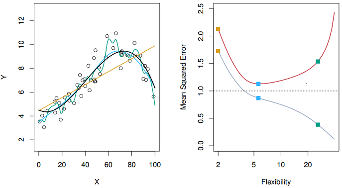

Figura 2.9 de [ISLP]

Esquerda: Dados simulados de $r$ (em preto), e três estimativas $g$ com diferentes complexidades. Direita: EQM de treinamento (cinza) e de teste (vermelho), em função da complexidade do modelo.

## Um exemplo mais concreto

- $X \sim \mathcal{U}[0, 2]$
- $f(x) = \sin(\pi x)$
- $Y = f(X) + \varepsilon$
- $\varepsilon \sim \mathcal{N}(0, 0.4)$
- Ajuste polinomial para diversos valores de $p$:
  $$g(x) = \beta_0 + \sum_{n = 1}^{p} \beta_n x^n$$
- Fonte: [Bias-variance trade-off with Python example](https://towardsdatascience.com/bias-variance-trade-off-with-python-example-6519d2084be4)

## Dados gerados segundo o modelo

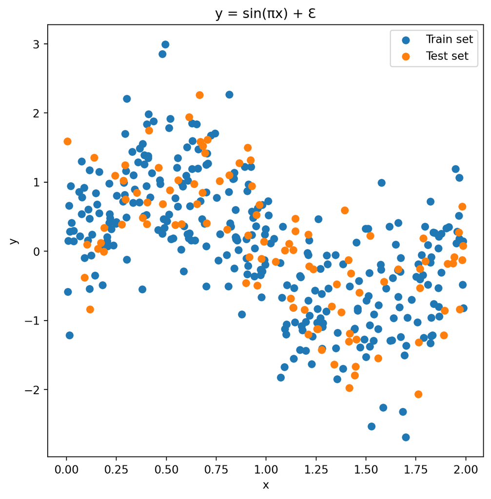

## Ajustes polinomiais

```
Best fit polynomial degree:  7
```

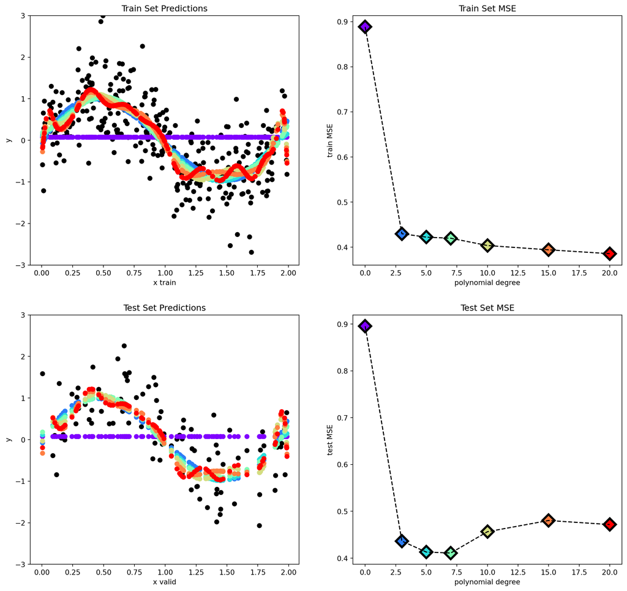

## Voltando à estimativa do risco

- Classe de modelos “candidatos”: $\mathbb{G}$
- Modelo $g$ com baixo EQM de treinamento **não** é bom sinal: ele pode estar se ajustando não só aos dados, mas também ao *ruído subjacente às observações* - *sobreajuste* ou *overfitting*
- Modelo $g$ com menor EQM de teste **também** não é o ideal: super-ajuste ao conjunto de teste! Isto é, isso pode levar à escolha de uma função $g$ que tenha bom desempenho preditivo no conjunto de teste, mas não em novas observações - mesmas observações usadas para comparar *todos* os $g$!

## Problema - Como estimar bem o risco e selecionar o melhor modelo?

- Conjunto de dados $(\mathbf{x}_{k}, y_{k})_{k = 1, \dots}$, i.i.d. segundo $(\mathbf{X}, Y)$
- $\mathbb{G}$ classe de modelos “candidatos” para ajustar aos dados
- Aferir “bem” a capacidade preditiva para “toda” $g \in \mathbb{G}$
- Escolher a $g \in \mathbb{G}$ com melhor capacidade de generalização fora do conjunto de dados inicial
- Escolher o melhor *hiperparâmetro* para alguma $g$
  - Exemplos de hiperparâmetros: $\lambda$ no Lasso ou Ridge, grau $p$ de um ajuste polinomial, etc…

# Validação cruzada

## Dividindo bem o conjunto de dados…

$$\underbrace{(\mathbf{x}_1, y_1), \dots, (\mathbf{x}_n, y_n)}_{\text{conjunto de treinamento}}, \underbrace{(\mathbf{x}_{n + 1}, y_{n + 1}), \dots, (\mathbf{x}_{n + m}, y_{n + m})}_{\text{conjunto de teste}}$$

- Aproximadamente 70% para treinamento e 30% para teste
  - Treinar modelo requer mais informação $\Rightarrow$ precisa de mais dados
  - Para ter uma boa estimativa do risco no conjunto de teste, menos dados são necessários

## …e fazendo bom uso deles!¹

¹ Especialmente do conjunto de treinamento!

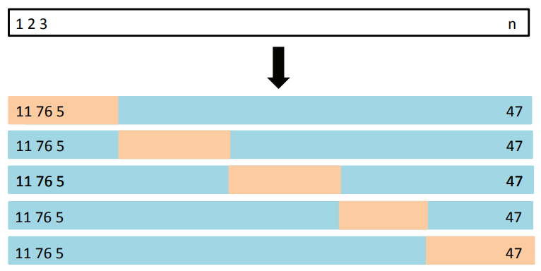

Figura 5.5 de [ISLP]

Ilustração esquemática da validação cruzada com $k$ dobras

## Validação cruzada com $k$ dobras

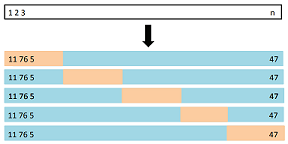

- Randomizar o conjunto de treinamento (por quê?)
- Dividir em $k$ partes iguais (“dobras”, “*fold*”)
- Primeira dobra: conjunto temporário de teste
- $k - 1$ outras dobras: conjunto temporário de treinamento
  - Treina um modelo $g_1$ e calcula seu EQM na primeira dobra
- Repete: $k$ observações de EQM

## Validação cruzada com $k$ dobras

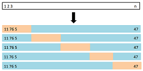

- $\mathrm{EQM}_i$, para $i = 1, \dots, k$
  - Modelos $g_i$ treinados no azul e testados no bege, para $i = 1, \dots, k$
- $\mathrm{EQM}_{k-\mathrm{VC}} = \frac{1}{k} \sum_{i = 1}^{k} \mathrm{EQM}_i$
- Atenção: Não mede a qualidade de um **ajuste** $g$ mas sim de um **modelo** $g$. Qual a diferença?!

## Como escolher o valor de $k$?

- $k = 1$: é o *data splitting* — uma divisão só, e aceita-se o que ela disser
  - “Treina no treino e testa no teste”: super-ajuste ao conjunto de teste
  - Não é um caso de $k$ dobras: com uma dobra só não sobra nada para treinar. O menor $k$ possível é 2, e o `KFold` recusa `n_splits=1`
- $k = n$: *Leave One Out Cross Validation* (LOOCV)
  - Requer $n$ ajustes do modelo; computacionalmente caro
- Tipicamente: $k$ entre 5 e 10
  - Por quê?
  - A resposta usa o *balanço entre o viés e a variância*

## Como escolher o valor de $k$?

- LOOCV
  - Treina $n$ modelos, cada um em $n - 1$ amostras
  - Modelos mais “bem treinados” $\Rightarrow$ mais próximos da “verdade” $\Rightarrow$ menor viés
  - Conjuntos com grande interseção entre si $\Rightarrow$ modelos muito correlacionados $\Rightarrow$ $\mathrm{EQM}_{n-\mathrm{VC}}$ com alta variância
  - O valor de $\mathrm{EQM}_{n-\mathrm{VC}}$ é menos confiável!

## Como escolher o valor de $k$?

- $k$-VC, com $k \ll n$
  - Conjuntos com **menos** interseção entre si $\Rightarrow$ modelos **menos** correlacionados $\Rightarrow$ $\mathrm{EQM}_{k-\mathrm{VC}}$ com **menor** variância $\Rightarrow$ valor **mais** confiável
  - E quanto ao viés? Se o conjunto de treinamento é “suficientemente grande” e o modelo não é “muito complexo”, em cada etapa o modelo provavelmente estará bem treinado $\Rightarrow$ baixo impacto no viés!
- Portanto, $k$ entre 5 e 10 faz sentido!

## E para escolher o melhor ajuste?

$$\underbrace{(\mathbf{x}_1, y_1), \dots, (\mathbf{x}_n, y_n)}_{\text{conjunto de treinamento}}, \underbrace{(\mathbf{x}_{n + 1}, y_{n + 1}), \dots, (\mathbf{x}_{n + m}, y_{n + m})}_{\text{conjunto de teste}}$$

- Escolhe(m)-se bom(ns) candidato(s) $g$ conforme o procedimento anterior
- Treina(m)-se tal(is) candidato(s) $g$ em todo o conjunto de treinamento. Por quê?
- Para o(s) modelo(s) $g$ conforme acima, testa-se o(s) seu(s) desempenho(s) no conjunto de teste
- Escolhe-se o melhor ajuste com base em tal desempenho

# Continuando no exemplo anterior

## Relembrando o exemplo

- $X \sim \mathcal{U}[0, 2]$
- $f(x) = \sin(\pi x)$
- $Y = f(X) + \varepsilon$
- $\varepsilon \sim \mathcal{N}(0, 0.4)$
- Como escolher o melhor valor de $p$ no ajuste polinomial?
  $$g(x) = \beta_0 + \sum_{n = 1}^{p} \beta_n x^n$$

## Implementando: os dados e as dobras

- Gerando dados já separados por treinamento e teste

  ```python
  n_obs_tr = 300
  n_obs_vl = 100
  degs = [0, 3, 5, 7, 10, 15, 20]

  x_tr, y_tr = generate_data(n_obs = n_obs_tr, err_stdv = np.sqrt(0.4))
  x_vl, y_vl = generate_data(n_obs = n_obs_vl, err_stdv = np.sqrt(0.4))
  ```

  - `generate_data` é o modelo da moldura anterior escrito em código: sorteia $x \sim \mathcal{U}[0,2]$ e devolve $y = \sin(\pi x) + \varepsilon$
  - Cuidado com o `np.sqrt(0.4)`: em $\varepsilon \sim \mathcal{N}(0, 0.4)$ o $0{,}4$ é a **variância**, e o `numpy` pede o **desvio-padrão**
  - `degs` é a classe de candidatos $\mathbb{G}$: sete graus, de $p = 0$ (só a média) a $p = 20$
  - As 100 observações `x_vl, y_vl` são o **conjunto de teste** — o sufixo vem de *validation*, mas o papel aqui é o de teste: ficam guardadas até o fim e não entram em dobra nenhuma
- Separando o conjunto de treinamento em $k$ dobras

  ```python
  kf = KFold(n_splits = 5, shuffle = True, random_state = 0)
  for i, (train_index, test_index) in enumerate(kf.split(x_tr, y_tr)):
    print(f"Dobra {i}: treino = {len(train_index)} obs, teste temporário = {len(test_index)} obs")
    print(f"  5 primeiros índices do teste temporário: {test_index[:5]}")
  ```

  ```
  Dobra 0: treino = 240 obs, teste temporário = 60 obs
    5 primeiros índices do teste temporário: [ 5  7  8 12 15]
  Dobra 1: treino = 240 obs, teste temporário = 60 obs
    5 primeiros índices do teste temporário: [18 20 21 27 33]
  Dobra 2: treino = 240 obs, teste temporário = 60 obs
    5 primeiros índices do teste temporário: [ 2  3  4 10 13]
  Dobra 3: treino = 240 obs, teste temporário = 60 obs
    5 primeiros índices do teste temporário: [ 0  6 11 23 35]
  Dobra 4: treino = 240 obs, teste temporário = 60 obs
    5 primeiros índices do teste temporário: [ 1  9 17 25 28]
  ```

  - `shuffle = True` embaralha antes de cortar: sem isso as dobras saem na ordem do arquivo, e um banco ordenado por data ou por classe daria dobras não representativas
  - `random_state = 0` fixa a partição. **Sem ele cada chamada a `split()` sorteia dobras diferentes** — inclusive a do laço da próxima moldura, que não usaria estas
  - 300 observações em 5 dobras: a cada rodada, 240 para treinar e 60 para avaliar
  - O `y_tr` em `kf.split(x_tr, y_tr)` é *ignorado* pelo `KFold`: está ali por compatibilidade com o `StratifiedKFold`, que precisa do $y$ para preservar a proporção das classes

## Implementando: o laço das dobras

Em cada dobra, ajusta os sete candidatos no treino temporário e mede o EQM no lote que ficou de fora

```python
mse_deg = {}

for i, (train_index, test_index) in enumerate(kf.split(x_tr, y_tr)):
  x_tr_aux = x_tr[train_index]
  y_tr_aux = y_tr[train_index]
  x_te_aux = x_tr[test_index]
  y_te_aux = y_tr[test_index]

  fit_coeffs = fit_poly_models(degs, x_tr_aux, y_tr_aux)
  y_te_aux_est = eval_poly_models(fit_coeffs, x_te_aux)
  mse_te_aux = comp_poly_mse(y_te_aux_est, y_te_aux)
  for k, v in mse_te_aux.items():
    if k in mse_deg:
      mse_deg[k].append(v)
    else:
      mse_deg[k] = [v]
print(mse_deg)
```

```
{'0': [1.0835319737812303, 0.9123508710126779, 0.8515078166111659, 0.8211992644333059, 0.906370276956641], '3': [0.4685550190713497, 0.4413105599865085, 0.5172188314619182, 0.38201835586616856, 0.3723633515396271], '5': [0.4463387593756728, 0.43852306378300354, 0.5256267862112263, 0.3826292538478435…
```

- `x_tr[train_index]` e `x_tr[test_index]`: os índices da moldura anterior viram os dados da rodada
- `fit_poly_models` ajusta os **sete** graus *dentro* da dobra — são $5 \times 7 = 35$ ajustes, e nenhum deles vê o lote em que será avaliado
- Ao final `mse_deg` guarda uma lista de 5 EQMs por grau (o `if`/`else` é um `setdefault`; um `defaultdict(list)` faria o mesmo)
- **Regra de ouro:** tudo o que aprende dos dados fica *dentro* do laço. Padronizar ou selecionar variáveis antes dele é vazamento (Aula 06)

## Implementando: a média e a escolha

A média das 5 dobras, grau a grau — é o $\mathrm{EQM}_{k-\mathrm{VC}}$

```python
mse_deg_mean = {}
for k, v in mse_deg.items():
  mse_deg_mean[k] = np.mean(np.array(v))

print(mse_deg_mean)

print("Best fit polynomial degree (OLD): ", degs[list(mse_vl.values()).index(min(list(mse_vl.values())))])

print("Best fit polynomial degree (NEW): ", degs[list(mse_deg_mean.values()).index(min(list(mse_deg_mean.values())))])
```

```
{'0': 0.9149920405590042, '3': 0.43629322358511435, '5': 0.4321016634878056, '7': 0.4408276044043342, '10': 0.45040167629488986, '15': 0.45951803150743126, '20': 0.5162979625038984}
Best fit polynomial degree (OLD):  7
Best fit polynomial degree (NEW):  5
```

- O `OLD` é o grau escolhido no começo da aula, por **uma única** divisão treino/teste: $p = 7$. O `NEW` é o que as 5 dobras escolhem: $p = 5$
- Mas olhe a dispersão: o desvio-padrão *entre as dobras* é $\approx 0{,}06$, e a distância do grau 5 ao grau 7 é $0{,}009$ — sete vezes menor
- Pela **regra de um erro-padrão** ($\mathrm{EP} = \mathrm{dp}/\sqrt{5} \approx 0{,}03$) os graus 3, 5, 7, 10 e 15 são *indistinguíveis*, e ficaríamos com o mais simples deles: $p = 3$
- O que a VC separa com folga é o ruim do razoável: o grau 0 está a **17** erros-padrão do mínimo. E a troca de 7 para 5 é, ela mesma, sinal de que a divisão única era ruído
- Falta o último passo: reajustar o grau escolhido em **todo** o conjunto de treinamento e só então medir no conjunto de teste